# Leafy Green Models

Dr. Clifton Baldwin[^1]

Dr. Don Schaffner[^2]

March 29, 2023

# Leafy Greens Models

## R Version R version 4.2.3 (2023-03-15) in RStudio 2023.03.0+386

```
[1] "TidyVerse package version 1.3.1"
[1] "rstatix statistical package version 0.7.0"
```

## Simulate Leafy Green Refridgeration Data

This notebook works with the data from Vehdahl’s dissertation:

### “CROSS-CONTAMINATION, MODELING, AND RISK ASSESSMENT FOR PATHOGENS ON FRESH- CUT PRODUCE” By Ann Charles Vegdahl, under the direction of Dr. Donald W. Schaffner, October 2017.

Brown et al. (2016) discuss truck trailer temperatures during transport of fresh-cut leafy greens. Although we used the actual data kindly provided by Brown et. al. for our research, it is not our data to share. Therefore, I will use statistics reported in the published paper to simulate “temperature” data in this notebook.

**Brown, W., Ryser, E., Gorman, L., Steinmaus, S., Vorst, K., 2016. *Transit temperatures experienced by fresh-cut leafy greens during cross-country shipment*. Food Control 61, 146–155. https://doi.org/10.1016/j.foodcont.2015.09.014**

Brown et al. 2016 states, “the Temptale 4® sensors recorded temperatures every 5 min.

“High temperature abuse above 5C occurred in 16 of 16 shipments but was minimal in most cases (0.1-6.7% of the duration of each run) and only occurred extensively in 18.75% or 3 of the shipments.”

“Twenty-four or thirty temperature loggers were placed on six pallets and along the sidewalls during the loading of each trailer.”

Looking at the tables in the paper, it appears the data is slightly skewed right. Although I suspect I could model the data roughly using a Normal distribution, will assume the temperature data adheres to a Weibull distribution for each truck. Although the Weibull distribution are only non-negative values, the actual temperature rarely went below 0. Furthermore we are modeling the impact of higher temperatures and not freezing. Therefore the Weibull distribution is sufficient for our purposes. One could shift the data left, if future studies look at the sub-zero temperatures.

There were 16 trucks. Brown et. al. (2016), “Twenty-four or thirty temperature loggers were placed on six pallets and along the sidewalls during the loading of each trailer.”

## Weibull Distribution

```r
# From Table 6 in Brown et al. 2016,
# temps = c(2.30, 2.23, 2.78, 1.91, 2.46, 2.41, 1.08, 1.58, 0.79,
#           2.19, 2.68, 2.92)

# From Table 2, I can make some very rough estimates of the statistics and use that information to simulate some data. Five truck routes had temps > 5C less than 1% of the time. Rarely did truck have a negative temperature. I will estimate using a Weibull distribution, despite that Weibull cannot be <0.

# Set a seed so that the data is reproducable
set.seed(123)
# Define a range of values for the shape and scale parameters of the Weibull
shape = round(runif(16, min=1.5, max = 6),digits = 4)
scale = round(runif(16, min=1.7, max=3.4),digits = 4)

# Duration of Trips from Table 5
hours <- c(31.17, 77.25, 76.58, 83.92, 47.92, 69.0, 60.92, 49.83)
# There were 16 trucks but only 8 times listed. So I double the vector
hours <- c(hours, hours)
# For each "probe"
n <- round(12.0*hours) # every 5 minutes is 12 per hour

# Since all probe readings are combined anyway,
#  just multiply n by the number of probes.
# I do not know how many have 24 and how many 30 probes.
# Randomly assign 50%-50%
# probes <- if_else(runif(16, 0, 1) < 0.5, 24, 30)
# n <- n * probes
# Adding these additional observations for every probe does not alter results.
# Therefore I am using just a set of observations "per truck"

# Generate 16 Weibull distributions
trucks <- list(n, shape, scale) %>%
  pmap(rweibull)

# Identify each of the 16 trucks
names(trucks) <- paste(1:16, "_", sep="")

rm(hours, n, shape, scale)
```

trucks is now a list of 16 arrays, with each array being the set of temperature values for that truck.

```r
# Clean up the simulated data
transit <- trucks %>%
  unlist() %>% as.data.frame() %>%
  rename(temp_c = ".") %>%
  rownames_to_column("truck_name") %>%
  separate(truck_name, c("truck_number", "minutes")) %>%
  mutate(truck_number = as.numeric(truck_number),
         minutes = strtoi(minutes) * 5,
         temp_c = round(temp_c, digits = 4)) %>%
  # Since all probe readings are combined anyway, do not bother specifying which probe
  bind_cols(probe_number = 1)

rm(trucks)
```

Anyone who wants to use their own data, read that data into the data.frame `transit`. Alternately one can modify the simulation to run this code with “different” temperature values.

transit has four numeric variables:

- truck_number - a numeric identifier for the different trucks (or locations)
- minutes - the elapsed minutes
- temp_c - the temperature in Celsius
- probe_number - optionally if the truck/location had multiple probes. Defaults to 1 when no different probes

```r
transit %>% str(.)
```

```
'data.frame':   11918 obs. of  4 variables:
 $ truck_number: num  1 1 1 1 1 1 1 1 1 1 ...
 $ minutes     : num  5 10 15 20 25 30 35 40 45 50 ...
 $ temp_c      : num  1.48 1.25 3.38 1.9 1.34 ...
 $ probe_number: num  1 1 1 1 1 1 1 1 1 1 ...
```

## Explore Temperature Statistics by Truck

| Truck_Number | Minimum | Maximum | Mean | Standard_Deviation | Median | Minutes | Observations |
| --- | --- | --- | --- | --- | --- | --- | --- |
| 1 | 0.15 | 4.33 | 1.90 | 0.70 | 1.92 | 1870 | 374 |
| 2 | 0.46 | 2.65 | 1.64 | 0.36 | 1.64 | 4635 | 927 |
| 3 | 0.23 | 3.79 | 2.02 | 0.69 | 2.03 | 4595 | 919 |
| 4 | 0.78 | 4.56 | 3.07 | 0.63 | 3.11 | 5035 | 1,007 |
| 5 | 1.23 | 4.48 | 2.97 | 0.60 | 3.02 | 2875 | 575 |
| 6 | 0.01 | 10.87 | 2.61 | 1.58 | 2.32 | 4140 | 828 |
| 7 | 0.50 | 4.50 | 2.55 | 0.72 | 2.57 | 3655 | 731 |
| 8 | 0.78 | 4.75 | 3.11 | 0.65 | 3.19 | 2990 | 598 |
| 9 | 0.65 | 4.48 | 2.56 | 0.71 | 2.59 | 1870 | 374 |
| 10 | 0.52 | 5.03 | 2.62 | 0.82 | 2.63 | 4635 | 927 |

[output cut: 6 more lines]

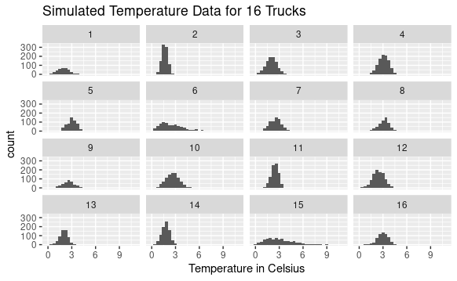

```r
transit %>%
  ggplot(aes(x = temp_c)) +
  geom_histogram(bins = 30) +
  labs(title = "Simulated Temperature Data for 16 Trucks",
       x = "Temperature in Celsius") +
  facet_wrap(~truck_number)
```

# Models

**One should not have to modify any of the code below**

Read in the different model parameters from Table 3 (corrected) of Vegdahl’s dissertation

```r
metrics <- read_csv("table3.csv", show_col_types = FALSE) %>%
  # standardize the metrics a bit (the remaining are standardized in logCFU())
  # hourly or daily
  mutate(b = if_else(grepl('h', Units, fixed = TRUE), b, b / sqrt(24.0))) %>%
         # square root or not
  mutate(b = if_else(grepl('√', Units, fixed = TRUE), b, sqrt(b)),
         logarithm = if_else(grepl('Ln', Units, fixed = TRUE), FALSE, TRUE),
         Source = str_remove_all(Source, "[()]"),
         Organism = paste(Organism, Source, sep = "\n"))
```

## Pseudo code

For each probe in each truck, compute the growth based on the current temperature and the given model.
$$\mu =
(b(T-T_0))^2$$

Compute the difference of current temperature T and minimum temperature (T<sub>0</sub>), call it Tdiff. If the Tdiff is negative, set it to 0.

If the model call is standard
$$\sqrt{log_{10}(CFU/hr/C)}$$
, then compute growth as ((((T - T<sub>0</sub>) * b)<sup>2</sup>) * (5.0 / 60)).

If the model call is
$$\sqrt{log_{10}
(CFU/day/C)}$$
, by day instead of by hour, then compute growth as ((((T - T<sub>0</sub>) * b)<sup>2</sup>) * (5.0 / 1440)), where 1440 = 60 * 24 or minutes in a day.

If the model call is log<sub>10</sub>(CFU/hr/C), then compute growth as ((((T - T<sub>0</sub>)<sup>2</sup> * b)) * (5.0 / 60)).

If the model call is
$$\sqrt{\ln(CFU/hr/C)}$$
, then compute growth as
$$\log_{10}(\exp^{((((T - T_0) *
b)^2) * (5.0 / 60))})$$
.

```r
# Compute the growth in log(CFU/time)
logCFU <- function(x){
  organism = x[1]
  b = as.numeric(x[2])
  T0 = as.numeric(x[3])
  source = x[4]
  logarithm = as.logical(x[5]) # Indicator for common or natural logarithm

  # Convert any natural logariths (i.e. ln) to common logs (i.e. base 10)
  b1 = if_else(logarithm, b, b/sqrt(log(10)))

  growth <- transit %>%
    select(truck_number, probe_number, minutes, temp_c) %>%
    group_by(truck_number, probe_number) %>%
    # If the temperature is below T0, set the difference to zero
    mutate(TdiffT0 = if_else(temp_c < T0, 0, temp_c - T0)) %>%
    mutate(Organism = organism, # The organism
           Source = source,     # The source reference and organism
           # Compute the Ratkowsky et al. equation
           growth = ((TdiffT0^2L) * (b1^2L)) * (5.0 / 60.0)
           )
  return(growth %>%
    group_by(Organism, Source, truck_number, probe_number) %>%
    # Return the total growth per probe_number
    summarise(growth = sum(growth),
              .groups = "keep") %>%
    add_column(b = b1, T0 = T0))
}
```

## Compute the growth given the data, models, and parameters

### All calculations complete

## Summary Graph

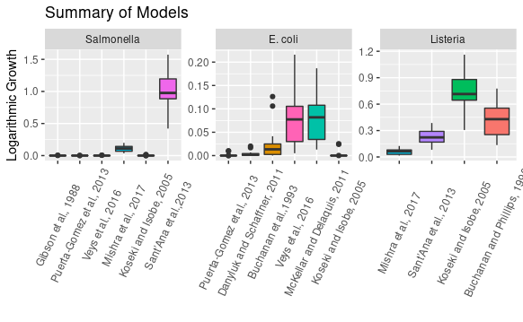

## Salmonella

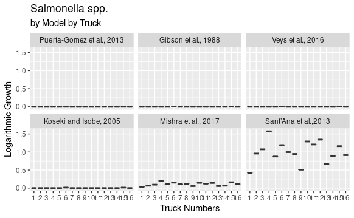

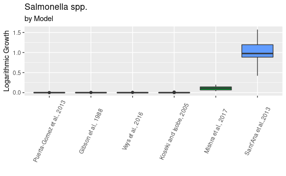

### Salmonella spp. Model Parameters and Statistics

Maximum is the truck with the most growth

| Model | b | T0 | Mean_growth | Maximum_growth |
| --- | --- | --- | --- | --- |
| Puerta-Gomez et al., 2013 | 0.01720465 | 5.880 | 0.0001706753 | 0.001488324 |
| Gibson et al., 1988 | 0.03700000 | 6.270 | 0.0004958350 | 0.004582451 |
| Veys et al., 2016 | 0.02700000 | 5.420 | 0.0007211291 | 0.006000732 |
| Koseki and Isobe, 2005 | 0.03300000 | 4.960 | 0.0018263512 | 0.014590998 |
| Mishra et al., 2017 | 0.01318020 | -0.571 | 0.1116578348 | 0.198683237 |
| Sant’Ana et al.,2013 | 0.01780000 | -4.600 | 1.0943144392 | 1.573214375 |

## Normality Test

In order to determine what statistical tests are appropriate, we need to understand our data.

The assumptions for the One-Way Repeated Measures ANOVA include:

```
Continuous
Normally Distributed
Random Sample
Enough Data
Sphericity
```

Most of the assumptions for between-subjects ANOVA design apply, however the key variation is that instead of the homogeneity of variance assumption, repeated-measures designs have the assumption of Sphericity, which means that the variance of the population difference scores for any two conditions should be the same as the variance of the population difference scores for any other two conditions.

Test of ANOVA assumptions: the data are normally distributed and the variance across groups are homogeneous http://www.sthda.com/english/wiki/one-way-anova-test-in-r

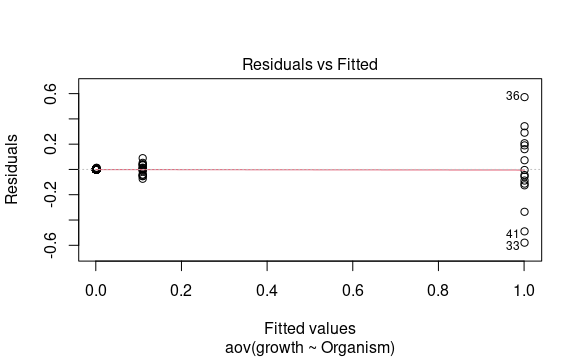

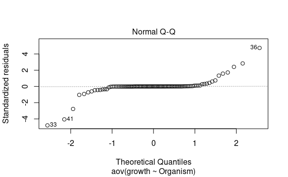

```
    Shapiro-Wilk normality test

data:  aov_residuals
W = 0.55775, p-value = 1.537e-15
```

Reject the null hypothesis that the data is Normal. Therefore a non parametric approach will be used.

## Friedman Test

### non parametric, repeated measures, one-way Analysis of Variance

|  | .y. | n | statistic | df | p | method |
| --- | --- | --- | --- | --- | --- | --- |
| 1 | growth | 16 | 75.37037 | 5 | 7.786114e-15 | Friedman test |

From the output of the Friedman test, we know that there is a significant difference between groups, but we do not know which pairs of groups are different. If the Friedman test is significant, post hoc tests to locate which pairs are different are needed. A significant Friedman test can be followed up by pairwise Wilcoxon signed-rank tests for identifying which groups are different.

The Wilcoxon signed-rank test is a non-parametric statistical hypothesis test used either to test the location of a set of samples or to compare the locations of two populations using a set of matched samples. The Bonferroni correction is a conservative adjustment where the p-values are multiplied by the number of comparisons.

| group1 | group2 | p.adj | p.adj.signif |
| --- | --- | --- | --- |
| Gibson et al., 1988 | Koseki and Isobe, 2005 | 1.000000 | ns |
| Gibson et al., 1988 | Mishra et al., 2017 | 0.000458 | *** |
| Gibson et al., 1988 | Puerta-Gomez et al., 2013 | 1.000000 | ns |
| Gibson et al., 1988 | Sant’Ana et al.,2013 | 0.000458 | *** |
| Gibson et al., 1988 | Veys et al., 2016 | 1.000000 | ns |
| Koseki and Isobe, 2005 | Mishra et al., 2017 | 0.000458 | *** |
| Koseki and Isobe, 2005 | Puerta-Gomez et al., 2013 | 1.000000 | ns |
| Koseki and Isobe, 2005 | Sant’Ana et al.,2013 | 0.000458 | *** |
| Koseki and Isobe, 2005 | Veys et al., 2016 | 1.000000 | ns |
| Mishra et al., 2017 | Puerta-Gomez et al., 2013 | 0.000458 | *** |

[output cut: 5 more lines]

|  | .y. | n | effsize | method | magnitude |
| --- | --- | --- | --- | --- | --- |
| 1 | growth | 16 | 0.9421296 | Kendall W | large |

The Kendall’s W coefficient assumes the value from 0 (indicating no relationship) to 1 (indicating a perfect relationship). So the effect is quite large between models with Kendall W = 0.94.

## E. coli

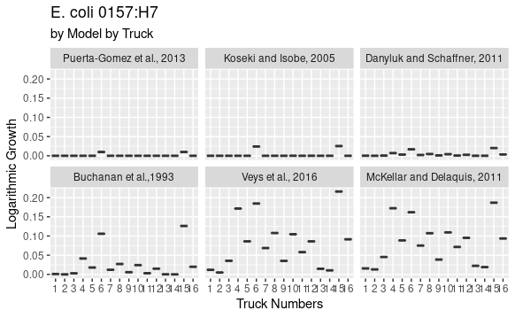

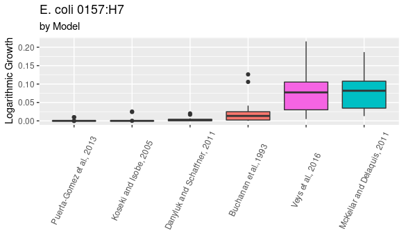

### E. coli 0157:H7 Model Parameters and Statistics

| Model | b | T0 | Mean_growth | Maximum_growth |
| --- | --- | --- | --- | --- |
| Puerta-Gomez et al., 2013 | 0.02459675 | 4.760 | 0.001255835 | 0.009945051 |
| Koseki and Isobe, 2005 | 0.03300000 | 4.450 | 0.003181267 | 0.025295154 |
| Danyluk and Schaffner, 2011 | 0.01257405 | 2.628 | 0.004164708 | 0.020157440 |
| Buchanan et al.,1993 | 0.03200000 | 2.670 | 0.026779321 | 0.126233458 |
| Veys et al., 2016 | 0.02800000 | 1.580 | 0.085178438 | 0.215928019 |
| McKellar and Delaquis, 2011 | 0.02300000 | 1.200 | 0.085717372 | 0.186803061 |

### Normality Test

Test of ANOVA assumptions: the data are normally distributed and the variance across groups are homogeneous http://www.sthda.com/english/wiki/one-way-anova-test-in-r

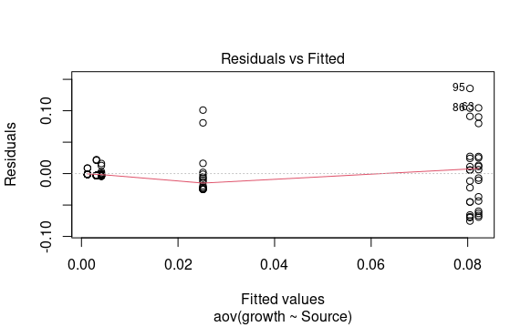

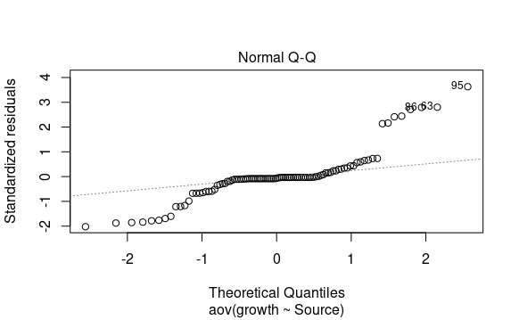

```
    Shapiro-Wilk normality test

data:  aov_residuals
W = 0.82212, p-value = 2.153e-09
```

Models appear to have heterogeneous variance, and Reject the null hypothesis that the data is Normal. Therefore a non parametric approach will be used.

## Friedman Test

### non parametric, repeated measures, one-way Analysis of Variance

|  | .y. | n | statistic | df | p | method |
| --- | --- | --- | --- | --- | --- | --- |
| 1 | growth | 16 | 75.27223 | 5 | 8.162151e-15 | Friedman test |

From the output of the Friedman test, we know that there is a significant difference between groups, but we do not know which pairs of groups are different.

A significant Friedman test can be followed up by pairwise Wilcoxon signed-rank tests for identifying which groups are different. The Wilcoxon signed-rank test is a non-parametric statistical hypothesis test used either to test the location of a set of samples or to compare the locations of two populations using a set of matched samples.

| group1 | group2 | p.adj | p.adj.signif |
| --- | --- | --- | --- |
| Buchanan et al.,1993 | Danyluk and Schaffner, 2011 | 0.000915 | *** |
| Buchanan et al.,1993 | Koseki and Isobe, 2005 | 0.011000 | * |
| Buchanan et al.,1993 | McKellar and Delaquis, 2011 | 0.000458 | *** |
| Buchanan et al.,1993 | Puerta-Gomez et al., 2013 | 0.011000 | * |
| Buchanan et al.,1993 | Veys et al., 2016 | 0.000458 | *** |
| Danyluk and Schaffner, 2011 | Koseki and Isobe, 2005 | 0.761000 | ns |
| Danyluk and Schaffner, 2011 | McKellar and Delaquis, 2011 | 0.000458 | *** |
| Danyluk and Schaffner, 2011 | Puerta-Gomez et al., 2013 | 0.000458 | *** |
| Danyluk and Schaffner, 2011 | Veys et al., 2016 | 0.000458 | *** |
| Koseki and Isobe, 2005 | McKellar and Delaquis, 2011 | 0.000458 | *** |

[output cut: 5 more lines]

|  | .y. | n | effsize | method | magnitude |
| --- | --- | --- | --- | --- | --- |
| 1 | growth | 16 | 0.9409029 | Kendall W | large |

The Kendall’s W coefficient assumes the value from 0 (indicating no relationship) to 1 (indicating a perfect relationship). So the effect is quite large between models with Kendall W = 0.94.

## Listeria monocytogenes

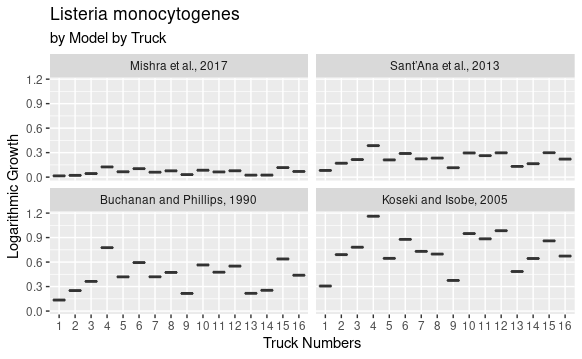

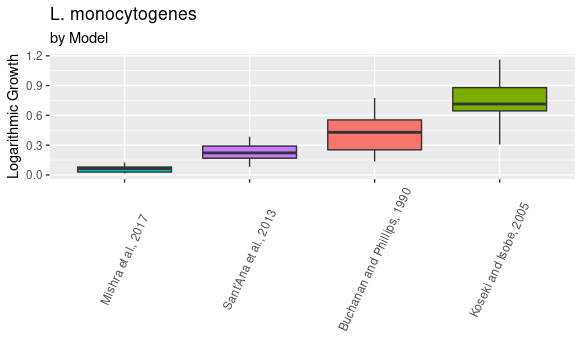

### Listeria monocytogenes Model Parameters and Statistics

| Model | b | T0 | Mean_growth | Maximum_growth |
| --- | --- | --- | --- | --- |
| Mishra et al., 2017 | 0.01515724 | 0.599 | 0.06408375 | 0.1250684 |
| Sant’Ana et al., 2013 | 0.01440000 | -1.600 | 0.23177735 | 0.3858339 |
| Buchanan and Phillips, 1990 | 0.02700000 | -0.440 | 0.45846118 | 0.7765212 |
| Koseki and Isobe, 2005 | 0.01600000 | -4.260 | 0.78633178 | 1.1616192 |

### Normality Test

Test of ANOVA assumptions: the data are normally distributed and the variance across groups are homogeneous http://www.sthda.com/english/wiki/one-way-anova-test-in-r

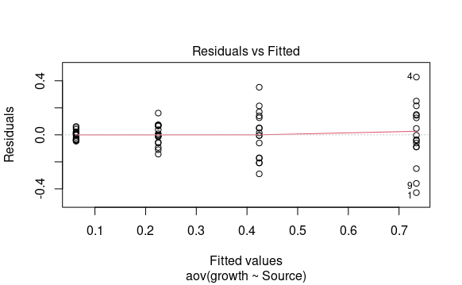

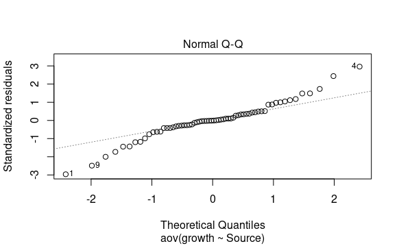

```
    Shapiro-Wilk normality test

data:  aov_residuals
W = 0.95625, p-value = 0.0235
```

Models appear to have heterogeneous variance and not follow a Normal distribution. Reject the null hypothesis that the data is Normal. Therefore a non parametric approach will be used.

## Friedman Test

### non parametric, repeated measures, one-way Analysis of Variance

|  | .y. | n | statistic | df | p | method |
| --- | --- | --- | --- | --- | --- | --- |
| 1 | growth | 16 | 48 | 3 | 2.129481e-10 | Friedman test |

From the output of the Friedman test, we know that there is a significant difference between groups, but we do not know which pairs of groups are different.

A significant Friedman test can be followed up by pairwise Wilcoxon signed-rank tests for identifying which groups are different. The Wilcoxon signed-rank test is a non-parametric statistical hypothesis test used either to test the location of a set of samples or to compare the locations of two populations using a set of matched samples.

| group1 | group2 | p.adj | p.adj.signif |
| --- | --- | --- | --- |
| Buchanan and Phillips, 1990 | Koseki and Isobe, 2005 | 0.000183 | *** |
| Buchanan and Phillips, 1990 | Mishra et al., 2017 | 0.000183 | *** |
| Buchanan and Phillips, 1990 | Sant’Ana et al., 2013 | 0.000183 | *** |
| Koseki and Isobe, 2005 | Mishra et al., 2017 | 0.000183 | *** |
| Koseki and Isobe, 2005 | Sant’Ana et al., 2013 | 0.000183 | *** |
| Mishra et al., 2017 | Sant’Ana et al., 2013 | 0.000183 | *** |

|  | .y. | n | effsize | method | magnitude |
| --- | --- | --- | --- | --- | --- |
| 1 | growth | 16 | 1 | Kendall W | large |

# References

The table of parameters (referenced as Table 3 (corrected) from Vegdahl’s dissertation), which was read and used in the computations above.

Models

| Organism | b | Units | T0 | Source |
| --- | --- | --- | --- | --- |
| Salmonella spp. | 0.033 | √Log CFU/h/°C | 4.96 | Koseki and Isobe, 2005 |
| Salmonella | 0.037 | √Log CFU/h/°C | 6.27 | Gibson et al., 1988 |
| S. enterica | 0.0178 | √Log CFU/h/°C | -4.6 | Sant’Ana et al.,2013 |
| S. typhymurium | 0.000296 | Log CFU/h/°C | 5.88 | Puerta-Gomez et al., 2013 |
| Salmonella spp. | 0.027 | √Log CFU/h/°C | 5.42 | Veys et al., 2016 |
| S. enterica | 0.02 | √Ln CFU/h/°C | -0.571 | Mishra et al., 2017 |
| E. coli O157:H7 | 0.033 | √Log CFU/h/°C | 4.45 | Koseki and Isobe, 2005 |
| E. coli O157:H7 | 0.032 | √Log CFU/h/°C | 2.67 | Buchanan et al.,1993 |
| E. coli O157:H7 | 0.0616 | √Log CFU/day/°C | 2.628 | Danyluk and Schaffner, 2011 |
| E. coli O157:H7 | 0.023 | √Log CFU/h/°C | 1.2 | McKellar and Delaquis, 2011 |
| E. coli O157:H7 | 0.000605 | Log CFU/h/°C | 4.76 | Puerta-Gomez et al., 2013 |
| E. coli O157:H7 | 0.028 | √Log CFU/h/°C | 1.58 | Veys et al., 2016 |
| L. monocytogenes | 0.016 | √Log CFU/h/°C | -4.26 | Koseki and Isobe, 2005 |
| L. monocytogenes | 0.027 | √Log CFU/h/°C | -0.44 | Buchanan and Phillips, 1990 |
| L. monocytogenes | 0.0144 | √Log CFU/h/°C | -1.6 | Sant’Ana et al., 2013 |
| L. monocytogenes | 0.023 | √Ln CFU/h/°C | 0.599 | Mishra et al., 2017 |

[^1]: Stockton University, Clifton.Baldwin@stockton.edu
[^2]: Rutgers University, don.schaffner@rutgers.edu